# Pruebas de hipótesis con Infer

Sergio Nava

## Stack_Overflow

```
##    tidyverse        infer        knitr summarytools
##         TRUE         TRUE         TRUE         TRUE
```

## Inferencia

Para esta parte trabajaremos con el conjunto de datos **Stack Overflow Developer Survey 2020** que se puede encontrar en https://www.kaggle.com/datasets/aitzaz/stack-overflow-developer-survey-2020.

A este conjunto de datos para los ejercicios se eliminaron los registros que no tenían valores en la variable *Age1stCode*

Primeros registros de la base de datos stack_overflow

| Respondent | MainBranch | Hobbyist | Age | Age1stCode | CompFreq | CompTotal | ConvertedComp | Country | CurrencyDesc | CurrencySymbol | DatabaseDesireNextYear | DatabaseWorkedWith | DevType | EdLevel | Employment | Ethnicity | Gender | JobFactors | JobSat | JobSeek | LanguageDesireNextYear | LanguageWorkedWith | MiscTechDesireNextYear | MiscTechWorkedWith | NEWCollabToolsDesireNextYear | NEWCollabToolsWorkedWith | NEWDevOps | NEWDevOpsImpt | NEWEdImpt | … |
| --- | --- | --- | --- | --- | --- | --- | --- | --- | --- | --- | --- | --- | --- | --- | --- | --- | --- | --- | --- | --- | --- | --- | --- | --- | --- | --- | --- | --- | --- | --- |
| 1 | I am a developer by profession | Yes | NA | 13 | Monthly | NA | NA | Germany | European Euro | EUR | Microsoft SQL Server | Elasticsearch;Microsoft SQL Server;Oracle | Developer, desktop or enterprise applications;Developer, full-stack | Master’s degree (M.A., M.S., M.Eng., MBA, etc.) | Independent contractor, freelancer, or self-employed | White or of European descent | Man | Languages, frameworks, and other technologies I’d be working with;Remote work options;Opportunities for professional development | Slightly satisfied | I am not interested in new job opportunities | C#;HTML/CSS;JavaScript | C#;HTML/CSS;JavaScript | .NET Core;Xamarin | .NET;.NET Core | Microsoft Teams;Microsoft Azure;Trello | Confluence;Jira;Slack;Microsoft Azure;Trello | No | Somewhat important | Fairly important | … |
| 2 | I am a developer by profession | No | NA | 19 | NA | NA | NA | United Kingdom | Pound sterling | GBP | NA | NA | Developer, full-stack;Developer, mobile | Bachelor’s degree (B.A., B.S., B.Eng., etc.) | Employed full-time | NA | NA | NA | Very dissatisfied | I am not interested in new job opportunities | Python;Swift | JavaScript;Swift | React Native;TensorFlow;Unity 3D | React Native | Github;Slack | Confluence;Jira;Github;Gitlab;Slack | NA | NA | Fairly important | … |
| 3 | I code primarily as a hobby | Yes | NA | 15 | NA | NA | NA | Russian Federation | NA | NA | NA | NA | NA | NA | NA | NA | NA | NA | NA | NA | Objective-C;Python;Swift | Objective-C;Python;Swift | NA | NA | NA | NA | NA | NA | NA | … |
| 4 | I am a developer by profession | Yes | 25 | 18 | NA | NA | NA | Albania | Albanian lek | ALL | NA | NA | NA | Master’s degree (M.A., M.S., M.Eng., MBA, etc.) | NA | White or of European descent | Man | Flex time or a flexible schedule;Office environment or company culture;Opportunities for professional development | Slightly dissatisfied | I’m not actively looking, but I am open to new opportunities | NA | NA | NA | NA | NA | NA | No | NA | Not at all important/not necessary | … |
| 5 | I used to be a developer by profession, but no longer am | Yes | 31 | 16 | NA | NA | NA | United States | NA | NA | MySQL;PostgreSQL | MySQL;PostgreSQL;Redis;SQLite | NA | Bachelor’s degree (B.A., B.S., B.Eng., etc.) | Employed full-time | White or of European descent | Man | NA | NA | NA | Java;Ruby;Scala | HTML/CSS;Ruby;SQL | Ansible;Chef | Ansible | Github;Google Suite (Docs, Meet, etc) | Confluence;Jira;Github;Slack;Google Suite (Docs, Meet, etc) | NA | NA | Very important | … |
| 6 | I am a developer by profession | No | NA | 14 | NA | NA | NA | Germany | European Euro | EUR | NA | NA | Designer;Developer, front-end;Developer, mobile | Secondary school (e.g. American high school, German Realschule or Gymnasium, etc.) | Employed full-time | White or of European descent | Man | Diversity of the company or organization;Languages, frameworks, and other technologies I’d be working with;Office environment or company culture | Slightly satisfied | I am not interested in new job opportunities | HTML/CSS;Java;JavaScript | HTML/CSS;Java;JavaScript | NA | NA | Github;Slack | Confluence;Github;Slack;Trello | Not sure | NA | Fairly important | … |

### Data Frame Summary

#### stack_overflow

**Dimensions:** 57473 x 61  
**Duplicates:** 0

| No | Variable | Stats / Values | Freqs (% of Valid) | Valid | Missing |
| --- | --- | --- | --- | --- | --- |
| 1 | Respondent [numeric] | Mean (sd) : 30930.1 (18891.4) min < med < max: 1 < 29214 < 65635 IQR (CV) : 33806 (0.6) | 57473 distinct values | 57473 (100.0%) | 0 (0.0%) |
| 2 | MainBranch [character] | 1. I am a developer by profe 2. I am a student who is lea 3. I am not primarily a deve 4. I code primarily as a hob 5. I used to be a developer | 42677 (74.4%) 6743 (11.8%) 4938 ( 8.6%) 1989 ( 3.5%) 979 ( 1.7%) | 57326 (99.7%) | 147 (0.3%) |
| 3 | Hobbyist [character] | 1. No 2. Yes | 12450 (21.7%) 45023 (78.3%) | 57473 (100.0%) | 0 (0.0%) |
| 4 | Age [numeric] | Mean (sd) : 30.8 (9.6) min < med < max: 1 < 29 < 279 IQR (CV) : 11 (0.3) | 87 distinct values | 45034 (78.4%) | 12439 (21.6%) |
| 5 | Age1stCode [numeric] | Mean (sd) : 15.5 (5.1) min < med < max: 5 < 15 < 85 IQR (CV) : 6 (0.3) | 61 distinct values | 57473 (100.0%) | 0 (0.0%) |
| 6 | CompFreq [character] | 1. Monthly 2. Weekly 3. Yearly | 18690 (47.1%) 1312 ( 3.3%) 19648 (49.6%) | 39650 (69.0%) | 17823 (31.0%) |
| 7 | CompTotal [numeric] | Mean (sd) : 2.893519e+145 (5.379144e+147) min < med < max: 0 < 62806.5 < 1e+150 IQR (CV) : 105000 (185.9) | 2984 distinct values | 34560 (60.1%) | 22913 (39.9%) |
| 8 | ConvertedComp [numeric] | Mean (sd) : 103504.8 (226487.4) min < med < max: 0 < 54000 < 2e+06 IQR (CV) : 70352 (2.2) | 6934 distinct values | 34492 (60.0%) | 22981 (40.0%) |
| 9 | Country [character] | 1. United States 2. India 3. Germany 4. United Kingdom 5. Canada [ 172 others ] | 11702 (20.4%) 6863 (11.9%) 3664 ( 6.4%) 3640 ( 6.3%) 2041 ( 3.6%) 29563 (51.4%) | 57473 (100.0%) | 0 (0.0%) |
| 10 | CurrencyDesc [character] | 1. United States dollar 2. European Euro 3. Indian rupee 4. Pound sterling 5. Canadian dollar [ 137 others ] | 10902 (24.3%) 9899 (22.1%) 4818 (10.8%) 3086 ( 6.9%) 1551 ( 3.5%) 14555 (32.5%) | 44811 (78.0%) | 12662 (22.0%) |
| 11 | CurrencySymbol [character] | 1. USD 2. EUR 3. INR 4. GBP 5. CAD [ 136 others ] | 10902 (24.3%) 9899 (22.1%) 4818 (10.8%) 3086 ( 6.9%) 1551 ( 3.5%) 14555 (32.5%) | 44811 (78.0%) | 12662 (22.0%) |
| 12 | DatabaseDesireNextYear [character] | 1. PostgreSQL 2. Microsoft SQL Server 3. MySQL 4. MongoDB 5. SQLite [ 3066 others ] | 2225 ( 5.4%) 1843 ( 4.4%) 1686 ( 4.1%) 1515 ( 3.6%) 910 ( 2.2%) 33331 (80.3%) | 41510 (72.2%) | 15963 (27.8%) |
| 13 | DatabaseWorkedWith [character] | 1. MySQL 2. Microsoft SQL Server 3. PostgreSQL 4. SQLite 5. Microsoft SQL Server;MySQ [ 2717 others ] | 3510 ( 7.5%) 3137 ( 6.7%) 1844 ( 4.0%) 1240 ( 2.7%) 1074 ( 2.3%) 35695 (76.8%) | 46500 (80.9%) | 10973 (19.1%) |
| 14 | DevType [character] | 1. Developer, full-stack 2. Developer, back-end 3. Developer, back-end;Devel 4. Developer, back-end;Devel 5. Developer, front-end [ 8171 others ] | 4377 ( 9.0%) 3060 ( 6.3%) 2209 ( 4.5%) 1460 ( 3.0%) 1385 ( 2.8%) 36277 (74.4%) | 48768 (84.9%) | 8705 (15.1%) |
| 15 | EdLevel [character] | 1. Bachelor’s degree (B.A., 2. Master’s degree (M.A., M. 3. Some college/university s 4. Secondary school (e.g. Am 5. Associate degree (A.A., A [ 4 others ] | 25985 (46.3%) 12827 (22.9%) 7070 (12.6%) 4676 ( 8.3%) 1811 ( 3.2%) 3714 ( 6.6%) | 56083 (97.6%) | 1390 (2.4%) |
| 16 | Employment [character] | 1. Employed full-time 2. Student 3. Independent contractor, f 4. Not employed, but looking 5. Employed part-time [ 2 others ] | 40823 (71.4%) 6795 (11.9%) 5126 ( 9.0%) 2040 ( 3.6%) 1959 ( 3.4%) 466 ( 0.8%) | 57209 (99.5%) | 264 (0.5%) |
| 17 | Ethnicity [character] | 1. White or of European desc 2. South Asian 3. Hispanic or Latino/a/x 4. Black or of African desce 5. Southeast Asian [ 196 others ] | 29080 (63.9%) 4419 ( 9.7%) 2241 ( 4.9%) 1662 ( 3.7%) 1662 ( 3.7%) 6428 (14.1%) | 45492 (79.2%) | 11981 (20.8%) |
| 18 | Gender [character] | 1. Man 2. Woman 3. Non-binary, genderqueer, 4. Man;Non-binary, genderque 5. Woman;Non-binary, genderq [ 2 others ] | 45529 (91.1%) 3769 ( 7.5%) 372 ( 0.7%) 119 ( 0.2%) 90 ( 0.2%) 93 ( 0.2%) | 49972 (86.9%) | 7501 (13.1%) |
| 19 | JobFactors [character] | 1. Flex time or a flexible s 2. Languages, frameworks, an 3. Flex time or a flexible s 4. Flex time or a flexible s 5. Flex time or a flexible s [ 225 others ] | 2758 ( 5.6%) 2546 ( 5.2%) 2488 ( 5.1%) 1659 ( 3.4%) 1645 ( 3.4%) 37738 (77.3%) | 48834 (85.0%) | 8639 (15.0%) |
| 20 | JobSat [character] | 1. Neither satisfied nor dis 2. Slightly dissatisfied 3. Slightly satisfied 4. Very dissatisfied 5. Very satisfied | 5700 (12.8%) 7060 (15.8%) 13810 (30.9%) 3681 ( 8.2%) 14447 (32.3%) | 44698 (77.8%) | 12775 (22.2%) |
| 21 | JobSeek [character] | 1. I am actively looking for 2. I am not interested in ne 3. I’m not actively looking, | 8736 (17.1%) 12828 (25.2%) 29389 (57.7%) | 50953 (88.7%) | 6520 (11.3%) |
| 22 | LanguageDesireNextYear [character] | 1. Python 2. Rust 3. HTML/CSS;JavaScript;TypeS 4. C# 5. Go [ 15588 others ] | 1019 ( 2.0%) 502 ( 1.0%) 476 ( 0.9%) 428 ( 0.8%) 382 ( 0.8%) 48102 (94.5%) | 50909 (88.6%) | 6564 (11.4%) |
| 23 | LanguageWorkedWith [character] | 1. HTML/CSS;JavaScript;PHP;S 2. HTML/CSS;JavaScript 3. C#;HTML/CSS;JavaScript;SQ 4. C#;HTML/CSS;JavaScript;SQ 5. HTML/CSS;JavaScript;TypeS [ 13711 others ] | 992 ( 1.8%) 818 ( 1.5%) 812 ( 1.5%) 726 ( 1.3%) 660 ( 1.2%) 49781 (92.5%) | 53789 (93.6%) | 3684 (6.4%) |
| 24 | MiscTechDesireNextYear [character] | 1. Node.js 2. Node.js;React Native 3. .NET;.NET Core 4. .NET Core 5. Flutter [ 5040 others ] | 3919 ( 9.7%) 1524 ( 3.8%) 1427 ( 3.5%) 1167 ( 2.9%) 947 ( 2.3%) 31448 (77.8%) | 40432 (70.3%) | 17041 (29.7%) |
| 25 | MiscTechWorkedWith [character] | 1. Node.js 2. .NET;.NET Core 3. .NET 4. .NET;.NET Core;Node.js 5. Pandas [ 2632 others ] | 6810 (17.7%) 3089 ( 8.0%) 2454 ( 6.4%) 1528 ( 4.0%) 1311 ( 3.4%) 23205 (60.4%) | 38397 (66.8%) | 19076 (33.2%) |
| 26 | NEWCollabToolsDesireNextYear [character] | 1. Github 2. Github;Gitlab 3. Github;Slack 4. Github;Slack;Google Suite 5. Github;Google Suite (Docs [ 1253 others ] | 4493 ( 9.9%) 1944 ( 4.3%) 1716 ( 3.8%) 1337 ( 3.0%) 1112 ( 2.5%) 34697 (76.6%) | 45299 (78.8%) | 12174 (21.2%) |
| 27 | NEWCollabToolsWorkedWith [character] | 1. Github 2. Github;Gitlab 3. Confluence;Jira;Github;Sl 4. Github;Google Suite (Docs 5. Github;Slack [ 1125 others ] | 4071 ( 8.1%) 1436 ( 2.8%) 1257 ( 2.5%) 1160 ( 2.3%) 1152 ( 2.3%) 41382 (82.0%) | 50458 (87.8%) | 7015 (12.2%) |
| 28 | NEWDevOps [character] | 1. No 2. Not sure 3. Yes | 18487 (43.7%) 5291 (12.5%) 18513 (43.8%) | 42291 (73.6%) | 15182 (26.4%) |
| 29 | NEWDevOpsImpt [character] | 1. Extremely important 2. Neutral 3. Not at all important 4. Not very important 5. Somewhat important | 19925 (48.2%) 7203 (17.4%) 588 ( 1.4%) 813 ( 2.0%) 12831 (31.0%) | 41360 (72.0%) | 16113 (28.0%) |
| 30 | NEWEdImpt [character] | 1. Critically important 2. Fairly important 3. Not at all important/not 4. Somewhat important 5. Very important | 4647 ( 9.7%) 12502 (26.2%) 7649 (16.0%) 11234 (23.6%) 11653 (24.4%) | 47685 (83.0%) | 9788 (17.0%) |
| 31 | NEWJobHunt [character] | 1. Curious about other oppor 2. Curious about other oppor 3. Better compensation 4. Curious about other oppor 5. Better compensation;Bette [ 2158 others ] | 1119 ( 2.7%) 1118 ( 2.7%) 783 ( 1.9%) 710 ( 1.7%) 657 ( 1.6%) 37485 (89.5%) | 41872 (72.9%) | 15601 (27.1%) |
| 32 | NEWJobHuntResearch [character] | 1. Read company media, such 2. Read company media, such 3. Read company media, such 4. Read company media, such 5. Read company media, such [ 58 others ] | 2424 ( 6.0%) 2386 ( 5.9%) 2144 ( 5.3%) 2042 ( 5.0%) 1943 ( 4.8%) 29715 (73.1%) | 40654 (70.7%) | 16819 (29.3%) |
| 33 | NEWLearn [character] | 1. Every few months 2. Once a decade 3. Once a year 4. Once every few years | 19286 (36.7%) 1155 ( 2.2%) 19446 (37.0%) 12599 (24.0%) | 52486 (91.3%) | 4987 (8.7%) |
| 34 | NEWOffTopic [character] | 1. No 2. Not sure 3. Yes | 18107 (36.7%) 19601 (39.7%) 11623 (23.6%) | 49331 (85.8%) | 8142 (14.2%) |
| 35 | NEWOnboardGood [character] | 1. No 2. Onboarding? What onboardi 3. Yes | 12554 (29.7%) 9163 (21.7%) 20515 (48.6%) | 42232 (73.5%) | 15241 (26.5%) |
| 36 | NEWOtherComms [character] | 1. No 2. Yes | 31717 (58.9%) 22164 (41.1%) | 53881 (93.8%) | 3592 (6.2%) |
| 37 | NEWOvertime [character] | 1. Never 2. Occasionally: 1-2 days pe 3. Often: 1-2 days per week 4. Rarely: 1-2 days per year 5. Sometimes: 1-2 days per m | 4649 (10.9%) 9394 (21.9%) 10927 (25.5%) 6390 (14.9%) 11459 (26.8%) | 42819 (74.5%) | 14654 (25.5%) |
| 38 | NEWPurchaseResearch [character] | 1. Start a free trial;Ask de 2. Start a free trial;Ask de 3. Start a free trial 4. Start a free trial;Ask de 5. Start a free trial;Visit [ 58 others ] | 7115 (19.9%) 4428 (12.4%) 3168 ( 8.9%) 3084 ( 8.6%) 2696 ( 7.5%) 15297 (42.7%) | 35788 (62.3%) | 21685 (37.7%) |
| 39 | NEWPurpleLink [character] | 1. Amused 2. Annoyed 3. Hello, old friend 4. Indifferent | 8385 (15.9%) 7448 (14.1%) 27319 (51.8%) 9625 (18.2%) | 52777 (91.8%) | 4696 (8.2%) |
| 40 | NEWSOSites [character] | 1. Stack Overflow (public Q& 2. Stack Overflow (public Q& 3. Stack Overflow (public Q& 4. Stack Overflow (public Q& 5. Stack Overflow (public Q& [ 55 others ] | 21221 (39.1%) 13248 (24.4%) 11521 (21.2%) 4269 ( 7.9%) 858 ( 1.6%) 3205 ( 5.9%) | 54322 (94.5%) | 3151 (5.5%) |
| 41 | NEWStuck [character] | 1. Call a coworker or friend 2. Visit Stack Overflow;Watc 3. Visit Stack Overflow 4. Call a coworker or friend 5. Call a coworker or friend [ 432 others ] | 2724 ( 5.1%) 2722 ( 5.1%) 2678 ( 5.1%) 2289 ( 4.3%) 2121 ( 4.0%) 40379 (76.3%) | 52913 (92.1%) | 4560 (7.9%) |
| 42 | OpSys [character] | 1. BSD 2. Linux-based 3. MacOS 4. Windows | 45 ( 0.1%) 14219 (26.6%) 13516 (25.2%) 25751 (48.1%) | 53531 (93.1%) | 3942 (6.9%) |
| 43 | OrgSize [character] | 1. 20 to 99 employees 2. 100 to 499 employees 3. 10,000 or more employees 4. 1,000 to 4,999 employees 5. 2 to 9 employees [ 4 others ] | 9523 (21.7%) 8240 (18.8%) 6074 (13.8%) 4829 (11.0%) 4346 ( 9.9%) 10867 (24.8%) | 43879 (76.3%) | 13594 (23.7%) |
| 44 | PlatformDesireNextYear [character] | 1. Linux 2. Windows 3. Linux;Windows 4. Docker;Linux 5. Android [ 7194 others ] | 1908 ( 4.0%) 1631 ( 3.4%) 1061 ( 2.2%) 763 ( 1.6%) 741 ( 1.5%) 41803 (87.3%) | 47907 (83.4%) | 9566 (16.6%) |
| 45 | PlatformWorkedWith [character] | 1. Windows 2. Linux;Windows 3. Linux 4. Android 5. Microsoft Azure;Windows [ 6074 others ] | 4454 ( 8.8%) 2332 ( 4.6%) 1995 ( 3.9%) 1059 ( 2.1%) 956 ( 1.9%) 39990 (78.7%) | 50786 (88.4%) | 6687 (11.6%) |
| 46 | PurchaseWhat [character] | 1. I have a great deal of in 2. I have little or no influ 3. I have some influence | 6615 (17.5%) 16398 (43.5%) 14715 (39.0%) | 37728 (65.6%) | 19745 (34.4%) |
| 47 | Sexuality [character] | 1. Straight / Heterosexual 2. Bisexual 3. Gay or Lesbian 4. Bisexual;Straight / Heter 5. Queer [ 9 others ] | 39787 (91.3%) 1891 ( 4.3%) 961 ( 2.2%) 255 ( 0.6%) 245 ( 0.6%) 446 ( 1.0%) | 43585 (75.8%) | 13888 (24.2%) |
| 48 | SOAccount [character] | 1. No 2. Not sure/can’t remember 3. Yes | 5673 (10.7%) 3177 ( 6.0%) 44345 (83.4%) | 53195 (92.6%) | 4278 (7.4%) |
| 49 | SOComm [character] | 1. Neutral 2. No, not at all 3. No, not really 4. Not sure 5. Yes, definitely 6. Yes, somewhat | 10917 (20.6%) 4544 ( 8.6%) 13956 (26.3%) 898 ( 1.7%) 8310 (15.7%) 14451 (27.2%) | 53076 (92.3%) | 4397 (7.7%) |
| 50 | SOPartFreq [character] | 1. A few times per month or 2. A few times per week 3. Daily or almost daily 4. I have never participated 5. Less than once per month 6. Multiple times per day | 7896 (17.9%) 3977 ( 9.0%) 2075 ( 4.7%) 9641 (21.9%) 19385 (43.9%) 1147 ( 2.6%) | 44121 (76.8%) | 13352 (23.2%) |
| 51 | SOVisitFreq [character] | 1. A few times per month or 2. A few times per week 3. Daily or almost daily 4. I have never visited Stac 5. Less than once per month 6. Multiple times per day | 7380 (13.9%) 12670 (23.8%) 16265 (30.5%) 117 ( 0.2%) 1567 ( 2.9%) 15284 (28.7%) | 53283 (92.7%) | 4190 (7.3%) |
| 52 | SurveyEase [character] | 1. Difficult 2. Easy 3. Neither easy nor difficul | 655 ( 1.3%) 34303 (67.0%) 16206 (31.7%) | 51164 (89.0%) | 6309 (11.0%) |
| 53 | SurveyLength [character] | 1. Appropriate in length 2. Too long 3. Too short | 38381 (75.2%) 10572 (20.7%) 2100 ( 4.1%) | 51053 (88.8%) | 6420 (11.2%) |
| 54 | Trans [character] | 1. No 2. Yes | 48385 (99.1%) 436 ( 0.9%) | 48821 (84.9%) | 8652 (15.1%) |
| 55 | UndergradMajor [character] | 1. Computer science, compute 2. Another engineering disci 3. Information systems, info 4. A natural science (such a 5. Mathematics or statistics [ 7 others ] | 31068 (62.0%) 4676 ( 9.3%) 3990 ( 8.0%) 2179 ( 4.4%) 1804 ( 3.6%) 6368 (12.7%) | 50085 (87.1%) | 7388 (12.9%) |
| 56 | WebframeDesireNextYear [character] | 1. React.js 2. ASP.NET Core 3. Vue.js 4. Spring 5. Express;React.js [ 3828 others ] | 2342 ( 6.2%) 1072 ( 2.8%) 1028 ( 2.7%) 959 ( 2.5%) 856 ( 2.3%) 31670 (83.5%) | 37927 (66.0%) | 19546 (34.0%) |
| 57 | WebframeWorkedWith [character] | 1. jQuery 2. React.js 3. Spring 4. Flask 5. Express;React.js [ 3652 others ] | 1939 ( 4.9%) 1821 ( 4.6%) 1276 ( 3.2%) 1033 ( 2.6%) 878 ( 2.2%) 33018 (82.6%) | 39965 (69.5%) | 17508 (30.5%) |
| 58 | WelcomeChange [character] | 1. A lot less welcome now th 2. A lot more welcome now th 3. Just as welcome now as I 4. Not applicable - I did no 5. Somewhat less welcome now 6. Somewhat more welcome now | 1956 ( 3.9%) 2955 ( 5.8%) 35999 (71.2%) 1918 ( 3.8%) 2955 ( 5.8%) 4806 ( 9.5%) | 50589 (88.0%) | 6884 (12.0%) |
| 59 | WorkWeekHrs [numeric] | Mean (sd) : 40.8 (17.8) min < med < max: 1 < 40 < 475 IQR (CV) : 4 (0.4) | 156 distinct values | 40822 (71.0%) | 16651 (29.0%) |
| 60 | YearsCode [character] | 1. 10 2. 5 3. 6 4. 7 5. 8 [ 47 others ] | 4480 ( 7.8%) 4223 ( 7.4%) 3814 ( 6.7%) 3460 ( 6.1%) 3401 ( 6.0%) 37770 (66.1%) | 57148 (99.4%) | 325 (0.6%) |
| 61 | YearsCodePro [character] | 1. 2 2. 3 3. 5 4. 4 5. 1 [ 47 others ] | 4781 (10.4%) 4781 (10.4%) 3947 ( 8.6%) 3693 ( 8.0%) 2796 ( 6.1%) 25945 (56.5%) | 45943 (79.9%) | 11530 (20.1%) |

## Hipótesis acerca de la media

**Una hipotésis:** La compensación anual media de la población de científicos de datos es de $101,000.

```r
(mean_comp_hyp <- 101000)
```

```
## [1] 101000
```

**La estimación puntual (muestra estadística):**

A continuación se presentan cuatro formas alternativas de obtener el promedio, el primero usa *R base*, el segundo *dplyr* y los dos últimos usan la biblioteca *infer*.

```r
x_bar <- mean(stack_overflow$ConvertedComp,na.rm = TRUE)

x_bar <- stack_overflow %>%
  summarise(mean_compensation= mean(ConvertedComp,na.rm = TRUE)) %>%
  pull(mean_compensation)

x_bar <- stack_overflow %>%
  specify(response = ConvertedComp) %>%
  calculate(stat = "mean") %>%
  pull(stat)

x_bar <- stack_overflow %>%
  observe(response = ConvertedComp, stat = "mean") %>%
  pull(stat)

x_bar
```

```
## [1] 103504.8
```

## Distribución nula

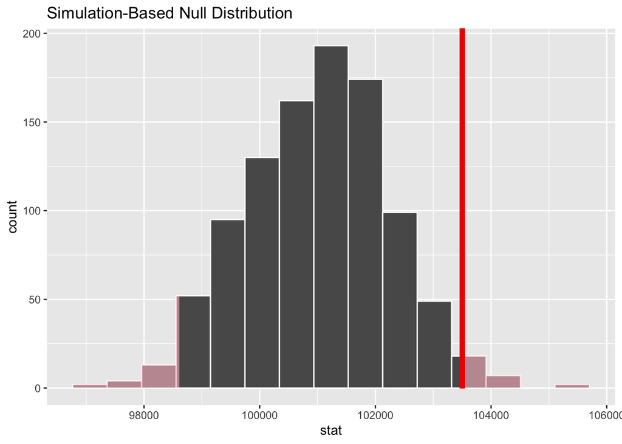

## Error estándar

```r
(std_error <- stack_overflow %>%
  select(ConvertedComp) %>%
  filter(!is.na(ConvertedComp)) %>%
  summarise(se = sd(ConvertedComp)/sqrt(n())) %>%
   pull(se))
```

```
## [1] 1219.509
```

## Z-scores / t-score

$$valor \: estandarizado = \frac{valor -
media}{desviación \: estándar}$$
$$z=\frac{estadística \: muestral - valor\:
hipotético\: del\: parámetro}{error \: estándar}$$

```r
x_bar
```

```
## [1] 103504.8
```

```r
mean_comp_hyp
```

```
## [1] 101000
```

```r
std_error
```

```
## [1] 1219.509
```

```r
(z_score <- (x_bar - mean_comp_hyp)/std_error)
```

```
## [1] 2.053974
```

$$z=\frac{ 103,504.84
- 101,000.00}{1,219.51}=2.054$$

## Prueba de hipótesis

¿Es 2.054 un número bajo o alto?

usando la distribución nula usando métodos teóricos usando *assume()*

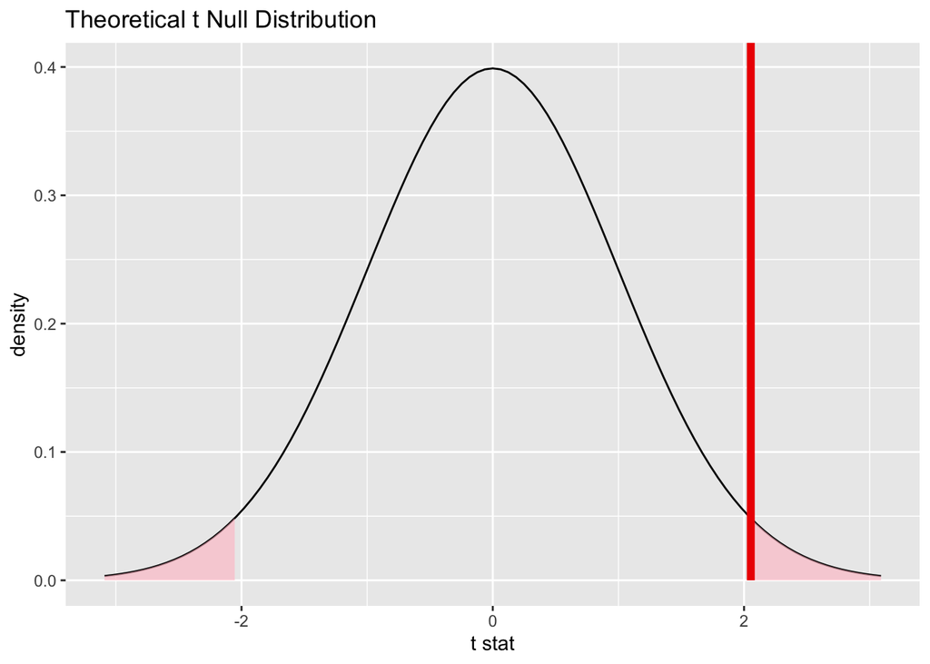

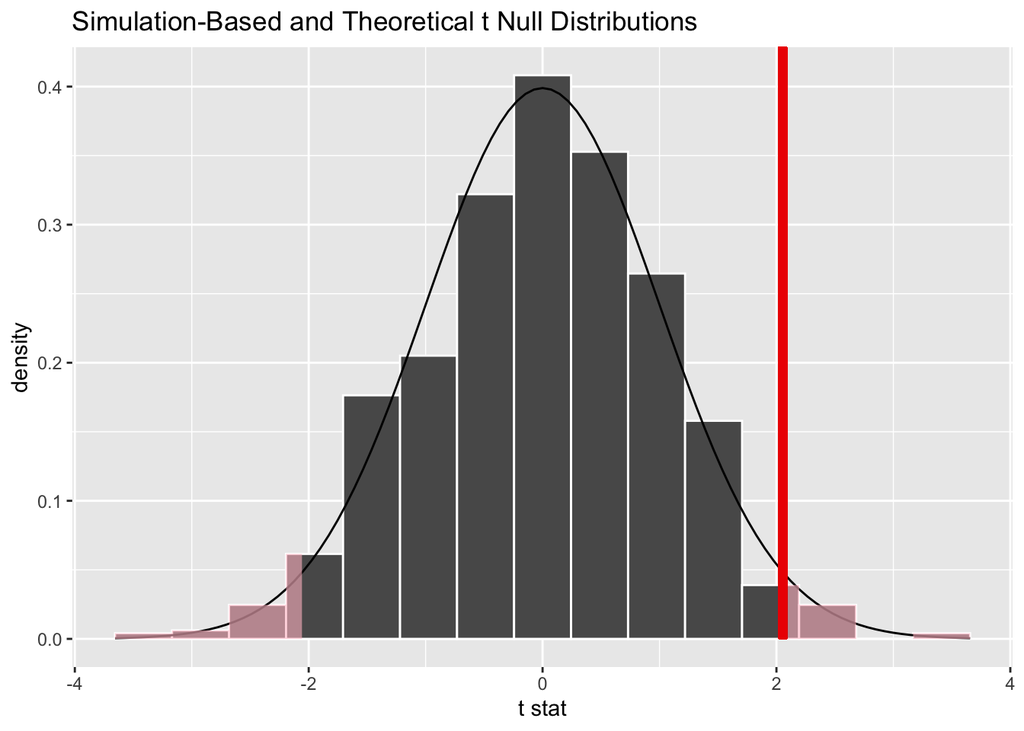

## Usando *t_test()*

```r
stack_overflow %>%
  t_test(response = ConvertedComp , mu = mean_comp_hyp)
```

```
## # A tibble: 1 × 7
##   statistic  t_df p_value alternative estimate lower_ci upper_ci
##       <dbl> <dbl>   <dbl> <chr>          <dbl>    <dbl>    <dbl>
## 1      2.05 34491  0.0400 two.sided    103505.  101115.  105895.
```

## Proporciones

```r
stack_overflow <- stack_overflow %>%
  mutate(age_first_code_cut = as.factor(ifelse(Age1stCode>= 14,
                                     "adult","child")))
stack_overflow %>% select(age_first_code_cut) %>% table()
```

```
## age_first_code_cut
## adult child
## 37656 19817
```

```r
#%>%  prop.table()
```

`age_first_code_cut` clasifica cuándo el usuario de Stack Overflow comenzó a programar por primera vez.

1. “adult” significa que comenzaron a los 14 años o más.

2. “child” significa que comenzaron antes de los 14 años.

Investigaciones anteriores sugieren que el 35% de los desarrolladores de software comenzaron a programar desde niños.

**¿Nuestra muestra proporciona evidencia de que los científicos de datos tienen una mayor proporción que comienzan a programar desde que eran niños?**

## Para nuestro problema

- Ho: La proporción de científicos de datos que comenzaron a programar cuando eran niños es de .35.
- Ha: La proporción de científicos de datos que comienzan a programar cuando son niños **no** es de .35.

## Calculando un z-score

```r
(prop_child_samp <- stack_overflow %>%
  summarize(point_estimate = mean(age_first_code_cut == "child",na.rm = TRUE)) %>%
  pull(point_estimate))
```

```
## [1] 0.3448054
```

```r
(n_prop<- sum(!is.na(stack_overflow$age_first_code_cut)))
```

```
## [1] 57473
```

```r
(prop_child_hyp <- 0.35)
```

```
## [1] 0.35
```

```r
(std_error <- sqrt(prop_child_hyp*(1-prop_child_hyp)/n_prop))
```

```
## [1] 0.001989568
```

```r
(z_score <- (prop_child_samp - prop_child_hyp)/std_error)
```

```
## [1] -2.610925
```

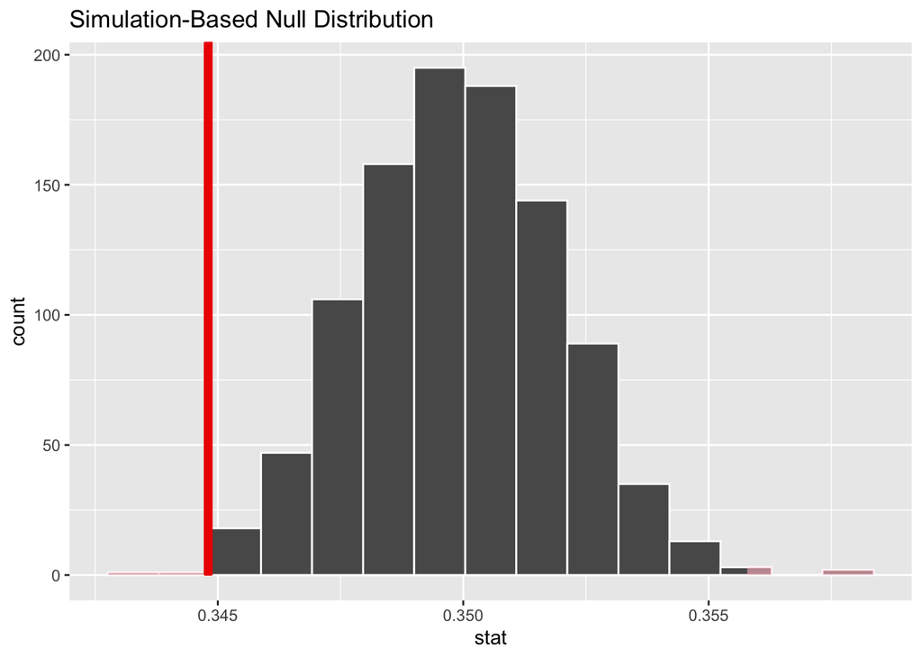

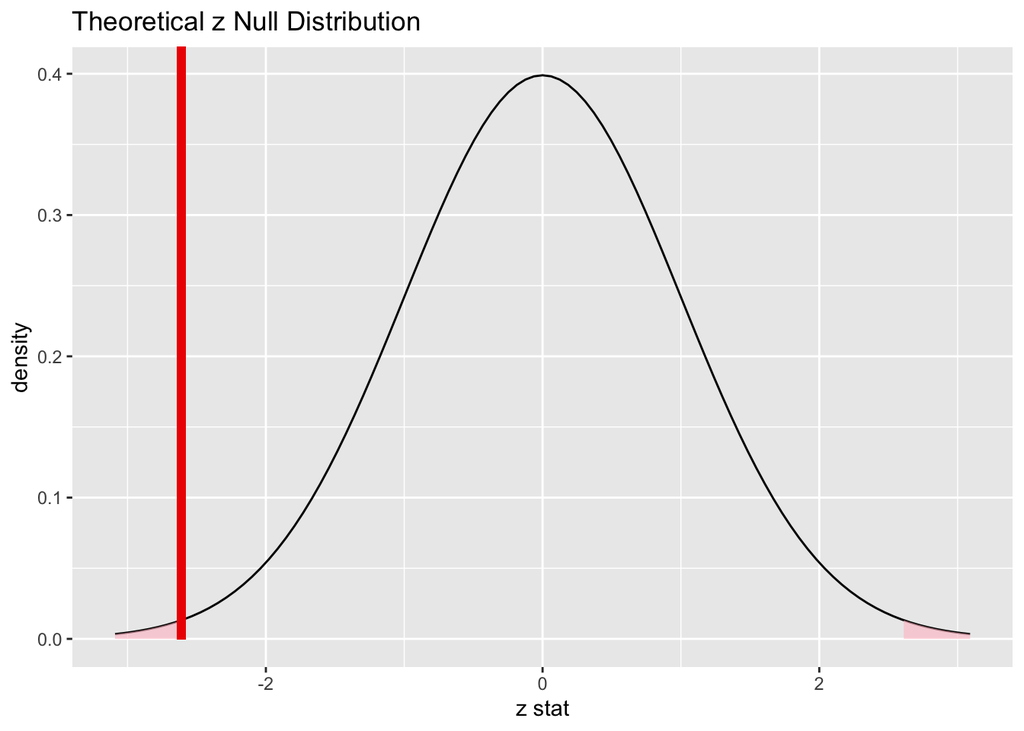

```r
stack_overflow %>%
  prop_test(age_first_code_cut ~ NULL,
            success = "child",
            p = prop_child_hyp,
            z=TRUE)
```

```
## # A tibble: 1 × 3
##   statistic p_value alternative
##       <dbl>   <dbl> <chr>
## 1     -2.61 0.00903 two.sided
```